# 231B - Section 12

Natalia Garbiras Díaz

# Today

- Course evaluations
- Data Snooping
- Multiple Comparison Adjustments
- Power Calculations (also see handout)

```r
# Library that we will need
library(mvtnorm)
```

# Data Snooping

We will compare two scenarios. In both scenarios, we will start with a design matrix with 50 independent variables with 100 observations and an outcome variable that is generated independently. That is, there is no true association between the outcome and any of the variables in the design matrix.

Case 1: The researcher runs a regression using all these variables and reports these results. Case 2: The researcher runs a regression using all these variables but instead of reporting these results, she screens the p-values and keeps just the variables that come up as significant in this first regression. Then, she runs a regression including only those variables. She only reports the results of this final regression.

To understand the distortions generated by data snooping, we will replicate these process 10,000 times and compare the proportion of significant p-values in the reported regression.

# Scenario 1

```r
# First let's create the variance-covariance matrix for the design matrix
# They will all be independent, so the off diagonal elements will be zero
varcov <- matrix(0, 50, 50)
diag(varcov) <- 1

noscreen <- function(n=100, design=50) {

    Y <- rnorm(n)

    # varcov matrix for the design matrix
    # independent, so the off diagonal elements will be zero
    varcov <- matrix(0, design, design)
    diag(varcov) <- 1
    # design matrix
    X <- rmvnorm(n, mean=rep(0, design), sigma=varcov)

    # regress Y on X, without an intercept
    fit <- summary(lm(Y ~ 0 + X))

    # return the proportion of coefficients significant at 0.05 level
    sum(fit$coefficients[,4] < 0.05)/design

}
```

# Scenario 2

```r
screen <- function(n=100,design=50) {

    Y <- rnorm(n)

    # varcov matrix for the design matrix
    # independent, so the off diagonal elements will be zero
    varcov <- matrix(0, design, design)
    diag(varcov) <- 1
    # design matrix
    X <- rmvnorm(n, mean=rep(0, design), sigma=varcov)

    # regress Y on X, without an intercept
    fit <- summary(lm(Y ~ 0 + X))

    # create a vector indicating the variables we should keep
    # (the significant ones)
    keeps <- fit$coefficients[,4]<0.05
    if (sum(keeps)>0){ Xscreen <- X[, keeps] }
    # if none is significant, we just keep all of them
    if (sum(keeps)==0) { Xscreen <- X }

    # regress Y on the keepers
    fit <- summary(lm(Y ~ 0 + Xscreen))

    # return the proportion of coefficients significant at 0.05 level
    # note that the total number of variables now is not "design" any more,
    # but the set that was significant in the first regression
    if (sum(keeps)>0){ prop <-sum(fit$coefficients[,4] < 0.05)/sum(keeps) }
    # if none is significant in the first reg, then denominator=design
    if (sum(keeps)==0){ prop <-sum(fit$coefficients[,4] < 0.05)/design }

    return(prop)

}
```

Let’s replicate each 10,000 times

```r
set.seed(1234)
H <- replicate(10000, noscreen(n=100, design=50))
H_screen <- replicate(10000, screen(n=100, design=50))
```

And compare the means

```r
mean(H)
```

```
## [1] 0.04987
```

```r
mean(H_screen)
```

```
## [1] 0.4259138
```

Let’s compare the distribution of the proportion of significant p-values

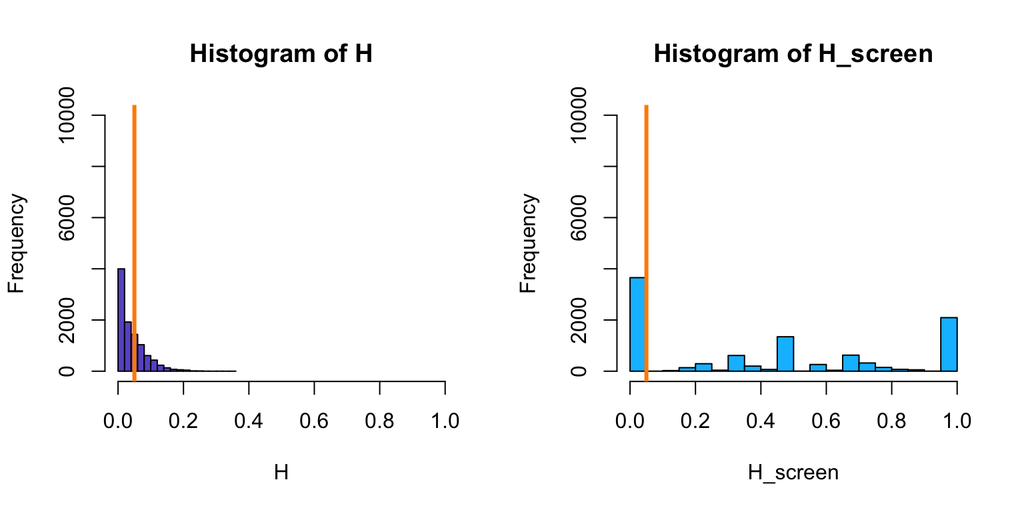

```r
par(mfrow=c(1, 2))
hist(H, col="slateblue", xlim=c(0, 1), breaks=25, ylim=c(0,10000))
abline(v=.05, col="darkorange", lwd=3)
hist(H_screen, col="deepskyblue", xlim=c(0, 1), breaks=25, ylim=c(0,10000))
abline(v=.05, col="darkorange", lwd=3)
```

How should we interpret these results?

# Multiple comparison adjustments

Bonferroni and FDR (false discovery rate)

Setup: here we have an experiment with 20 outcomes and a treatment assignment vector. The covariates will have a covariance of .2 (is this likely to be the case in applications?)

```r
set.seed(55)
varcov <- matrix(0.2, 20, 20)
diag(varcov) <- 1
Y <- rmvnorm(100, mean=rep(0, 20), sigma=varcov)

t <- rbinom(100, 1, .5)
```

First we will look at the individual tests. For this, we will need our t-test function.

```r
source("~/Dropbox/Academic/R/R_Functions/t_test.R")
```

And now for each variable, we run a t-test.

```r
results <- matrix(NA, 20, 8)
for (i in 1:ncol(Y)){ results[i,] <- ttest(Y[,i], t) }
colnames(results) <- c("Mean 1", "Mean 0", "Difference",
                  "SE Diff","t-stat", "N", "df", "p-value")
rownames(results) <- paste("outcome", 1:20, sep=" ")
```

```r
results
```

```
##                  Mean 1      Mean 0   Difference   SE Diff      t-stat   N
## outcome 1  -0.035871016 -0.02193532 -0.013935696 0.1944155 -0.07167995 100
## outcome 2   0.128410917  0.05199857  0.076412347 0.1951781  0.39150054 100
## outcome 3  -0.003296738 -0.04729509  0.043998354 0.1904393  0.23103610 100
## outcome 4   0.026733446 -0.04148776  0.068221210 0.2140792  0.31867283 100
## outcome 5  -0.163106521 -0.03217160 -0.130934917 0.2135066 -0.61325938 100
## outcome 6  -0.188992231 -0.01627948 -0.172712749 0.1895453 -0.91119525 100
## outcome 7   0.018946433  0.22533085 -0.206384415 0.1886389 -1.09407108 100
## outcome 8   0.089320817  0.13446275 -0.045141935 0.2062277 -0.21889367 100
## outcome 9  -0.117413818 -0.05774526 -0.059668562 0.1813005 -0.32911425 100
## outcome 10  0.064439753  0.34133416 -0.276894407 0.1816894 -1.52399910 100
## outcome 11 -0.005670651 -0.08607647  0.080405820 0.2163492  0.37164840 100
## outcome 12 -0.157224840  0.36136764 -0.518592482 0.1954348 -2.65353155 100
## outcome 13  0.105583031  0.09874755  0.006835479 0.2064868  0.03310371 100
## outcome 14  0.066578843 -0.10592358  0.172502425 0.2182757  0.79029621 100
## outcome 15 -0.162338596 -0.04438791 -0.117950681 0.2024585 -0.58259202 100
## outcome 16  0.107665464  0.07400591  0.033659557 0.1883117  0.17874380 100
## outcome 17  0.047269285  0.22530146 -0.178032178 0.2081104 -0.85546980 100
## outcome 18 -0.251096989  0.14187082 -0.392967810 0.2045000 -1.92160253 100
## outcome 19 -0.059178233 -0.09250591  0.033327675 0.2036145  0.16368028 100
## outcome 20 -0.037430306  0.05349256 -0.090922866 0.1939209 -0.46886568 100
##                  df     p-value
## outcome 1  95.18810 0.943007001
## outcome 2  95.09722 0.696303160
## outcome 3  92.76355 0.817795571
## outcome 4  96.43609 0.750663785
## outcome 5  94.29439 0.541181288
## outcome 6  97.72276 0.364434727
## outcome 7  97.96219 0.276606695
## outcome 8  91.56810 0.827220035
## outcome 9  86.15353 0.742868070
## outcome 10 97.61578 0.130742218
## outcome 11 81.91251 0.711114290
## outcome 12 94.95363 0.009338428
## outcome 13 85.14516 0.973669361
## outcome 14 94.68799 0.431329629
## outcome 15 81.72085 0.561772053
## outcome 16 89.89196 0.858541113
## outcome 17 93.61624 0.394475299
## outcome 18 95.85555 0.057626205
## outcome 19 95.42428 0.870329018
## outcome 20 96.48934 0.640223270
```

Bonferroni: now the reference level is:

```r
bonf <- .05/length(results[,8])
bonf
```

```
## [1] 0.0025
```

We will add a column indicating if we reject the null using this new reference level

```r
bonferroni_reject <- results[,8] <= bonf
results <- cbind(results, bonferroni_reject)
results
```

```
##                  Mean 1      Mean 0   Difference   SE Diff      t-stat   N
## outcome 1  -0.035871016 -0.02193532 -0.013935696 0.1944155 -0.07167995 100
## outcome 2   0.128410917  0.05199857  0.076412347 0.1951781  0.39150054 100
## outcome 3  -0.003296738 -0.04729509  0.043998354 0.1904393  0.23103610 100
## outcome 4   0.026733446 -0.04148776  0.068221210 0.2140792  0.31867283 100
## outcome 5  -0.163106521 -0.03217160 -0.130934917 0.2135066 -0.61325938 100
## outcome 6  -0.188992231 -0.01627948 -0.172712749 0.1895453 -0.91119525 100
## outcome 7   0.018946433  0.22533085 -0.206384415 0.1886389 -1.09407108 100
## outcome 8   0.089320817  0.13446275 -0.045141935 0.2062277 -0.21889367 100
## outcome 9  -0.117413818 -0.05774526 -0.059668562 0.1813005 -0.32911425 100
## outcome 10  0.064439753  0.34133416 -0.276894407 0.1816894 -1.52399910 100
## outcome 11 -0.005670651 -0.08607647  0.080405820 0.2163492  0.37164840 100
## outcome 12 -0.157224840  0.36136764 -0.518592482 0.1954348 -2.65353155 100
## outcome 13  0.105583031  0.09874755  0.006835479 0.2064868  0.03310371 100
## outcome 14  0.066578843 -0.10592358  0.172502425 0.2182757  0.79029621 100
## outcome 15 -0.162338596 -0.04438791 -0.117950681 0.2024585 -0.58259202 100
## outcome 16  0.107665464  0.07400591  0.033659557 0.1883117  0.17874380 100
## outcome 17  0.047269285  0.22530146 -0.178032178 0.2081104 -0.85546980 100
## outcome 18 -0.251096989  0.14187082 -0.392967810 0.2045000 -1.92160253 100
## outcome 19 -0.059178233 -0.09250591  0.033327675 0.2036145  0.16368028 100
## outcome 20 -0.037430306  0.05349256 -0.090922866 0.1939209 -0.46886568 100
##                  df     p-value bonferroni_reject
## outcome 1  95.18810 0.943007001                 0
## outcome 2  95.09722 0.696303160                 0
## outcome 3  92.76355 0.817795571                 0
## outcome 4  96.43609 0.750663785                 0
## outcome 5  94.29439 0.541181288                 0
## outcome 6  97.72276 0.364434727                 0
## outcome 7  97.96219 0.276606695                 0
## outcome 8  91.56810 0.827220035                 0
## outcome 9  86.15353 0.742868070                 0
## outcome 10 97.61578 0.130742218                 0
## outcome 11 81.91251 0.711114290                 0
## outcome 12 94.95363 0.009338428                 0
## outcome 13 85.14516 0.973669361                 0
## outcome 14 94.68799 0.431329629                 0
## outcome 15 81.72085 0.561772053                 0
## outcome 16 89.89196 0.858541113                 0
## outcome 17 93.61624 0.394475299                 0
## outcome 18 95.85555 0.057626205                 0
## outcome 19 95.42428 0.870329018                 0
## outcome 20 96.48934 0.640223270                 0
```

# Benjamini-Hochberg Procedure

For FDR, we will need to order the results according to the p-values

```r
order <- order(results[,8], decreasing=FALSE)
results <- results[order, ]
```

Define $k$ as the largest $i$ for which:

$$p(i)\leq\frac{i}{m}\alpha$$

FDR referece

```r
fdr_ref <- .05 * (1:20 / 20)
```

Now we compare each observed p-value to its reference

```r
results[,8] <= fdr_ref
```

```
## outcome 12 outcome 18 outcome 10  outcome 7  outcome 6 outcome 17
##      FALSE      FALSE      FALSE      FALSE      FALSE      FALSE
## outcome 14  outcome 5 outcome 15 outcome 20  outcome 2 outcome 11
##      FALSE      FALSE      FALSE      FALSE      FALSE      FALSE
##  outcome 9  outcome 4  outcome 3  outcome 8 outcome 16 outcome 19
##      FALSE      FALSE      FALSE      FALSE      FALSE      FALSE
##  outcome 1 outcome 13
##      FALSE      FALSE
```

How should we proceed now?

## Power Analysis

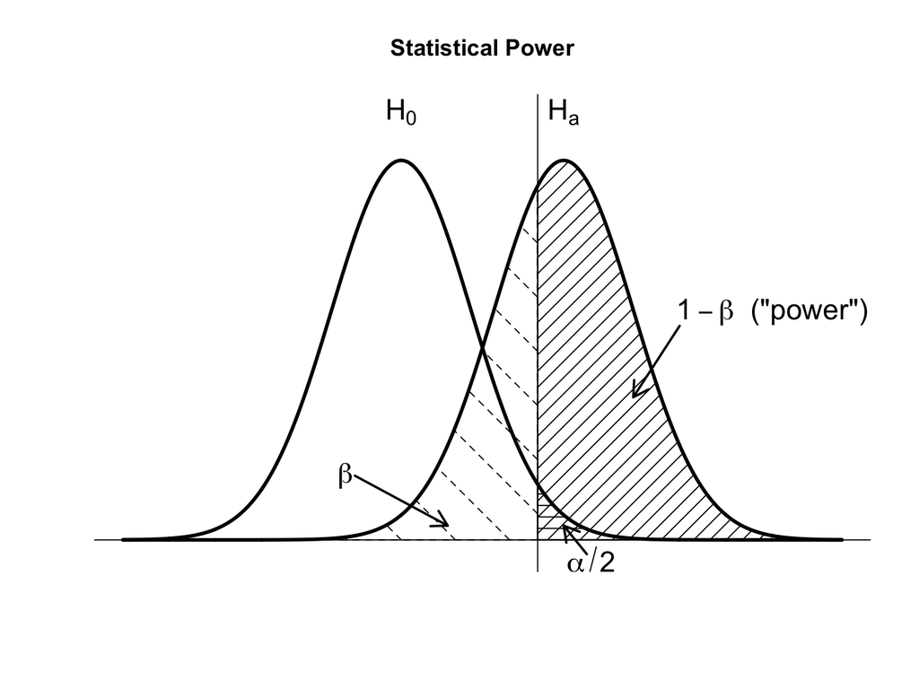

Under $H_0$ the distribution of the $\tau$ is approximately $N(\mu_0,\text{Var}(\hat{\tau}))$. Under $H_1$, the ATE is approximately distributed $N(\mu_1, \text{Var}(\hat{\tau}))$.

For a given value of $\mu_1$, power is the proportion of the $H_1$ distribution beyond the critical value (of a two-tailed hypothesis test).

Here $\beta$ is the probability of Type II error (i.e., false negative):

$$\beta = 1 - \Phi(\tau_{\text{critical under the alternative}})$$

This involves a lot of guesswork…

# Analytic formula (Gerber & Green 2012, p. 93)

(NOTE: This formula has some assumptions)

$$power = \Phi \bigg(\frac{\mid \mu_T - \mu_C \mid \sqrt{N}}{2\sigma} - \Phi^1(1 - \frac{\alpha}{2}) \bigg)$$

# Power with simulations

```r
sample_size <- seq(from=100, to=2000, by=10)

alpha <- 0.05

# placeholder
power <- rep(NA, length(sample_size))
sims <- 100

#### Loop to varying the number of subjects

for (j in 1:length(sample_size)){

    N <- sample_size[j]

    significant <- rep(NA, sims)

    for (i in 1:sims){

        # Potential outcomes
        Y0 <-  rnorm(n=N, mean=60, sd=20)
        tau <- 5                                       # hypothesized treatment effect
        Y1 <- Y0 + tau

        # Simulate random assignment
        treat <- rbinom(n=N, size=1, prob=.5)

        # observed outcomes
        Y_obs <- ifelse(treat==1, Y1, Y0)

        fit.sim <- t.test(Y_obs ~ treat)

        significant[i] <- (fit.sim$p.value <= alpha)

}

# store average success rate (power) for each N
power[j] <- mean(significant)

}

power
```

```
##   [1] 0.30 0.34 0.25 0.28 0.40 0.42 0.34 0.35 0.36 0.36 0.39 0.50 0.38 0.54
##  [15] 0.47 0.48 0.59 0.59 0.51 0.48 0.65 0.59 0.50 0.59 0.66 0.67 0.63 0.64
##  [29] 0.69 0.76 0.66 0.72 0.69 0.74 0.81 0.75 0.72 0.83 0.71 0.78 0.80 0.80
##  [43] 0.83 0.80 0.81 0.82 0.82 0.84 0.89 0.93 0.88 0.88 0.86 0.86 0.84 0.88
##  [57] 0.86 0.87 0.95 0.91 0.93 0.91 0.94 0.82 0.95 0.93 0.93 0.92 0.93 0.93
##  [71] 0.93 0.97 0.96 0.97 0.96 0.96 0.99 0.93 1.00 0.96 0.97 0.93 0.93 0.96
##  [85] 0.96 0.96 0.98 1.00 0.97 0.96 1.00 1.00 0.99 0.98 0.98 0.98 0.98 0.99
##  [99] 0.99 0.99 1.00 1.00 0.99 0.99 0.98 1.00 0.99 0.98 1.00 0.99 0.99 0.99
## [113] 1.00 1.00 0.99 0.99 1.00 1.00 1.00 0.99 1.00 0.99 1.00 1.00 1.00 0.98
## [127] 1.00 1.00 1.00 1.00 1.00 0.99 1.00 1.00 1.00 0.99 1.00 1.00 0.99 1.00
## [141] 1.00 1.00 1.00 1.00 0.99 0.98 1.00 1.00 0.98 1.00 1.00 1.00 1.00 1.00
## [155] 1.00 0.99 1.00 1.00 1.00 1.00 1.00 1.00 1.00 1.00 1.00 1.00 1.00 1.00
## [169] 1.00 0.99 1.00 1.00 1.00 0.99 1.00 0.99 1.00 1.00 1.00 1.00 1.00 1.00
## [183] 1.00 1.00 1.00 1.00 1.00 1.00 1.00 1.00 1.00
```

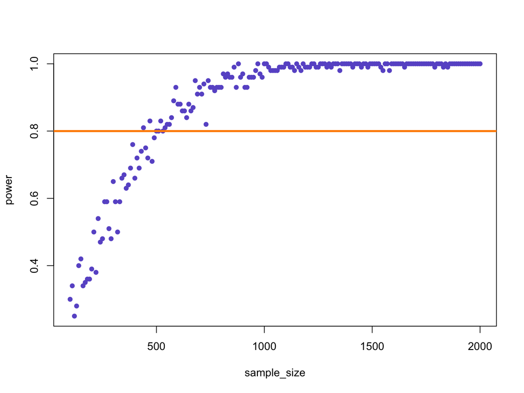

```r
par(mfrow=c(1,1))
plot(sample_size, power, col="slateblue", pch=16)
abline(h=.8, col="darkorange", lwd=3)
```